# Project 2 Report

### ANOVA Models

For the ANOVA models used in the report, we want to check for the following indicators that the assumptions do not hold.

- Outliers
- Unequal variance in the error terms
- THe error terms not being distributed normally
- Error terms are correlated

To check for any of these, we will look at the same plots as we did for the linear model.

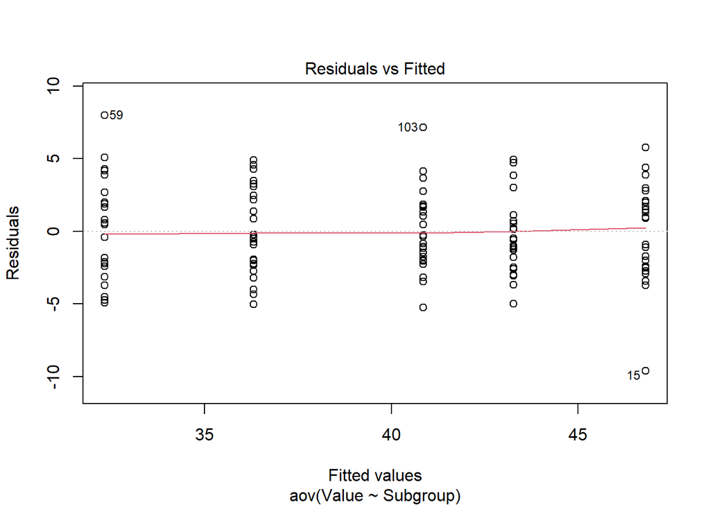

For the race ANOVA model, we see that the residuals are evenly and seemingly randomly distributed on either side of the regression line. Nothing concerning here.

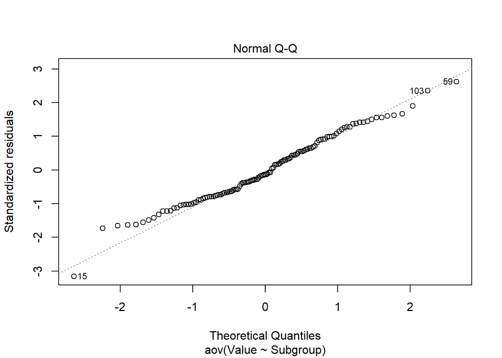

The normal Q-Q plot does contain some tailing at either end of the sample which is mildly concerning. However, this tailing is not significant enough to conclude that our model assumption of normally distributed error terms do not hold.

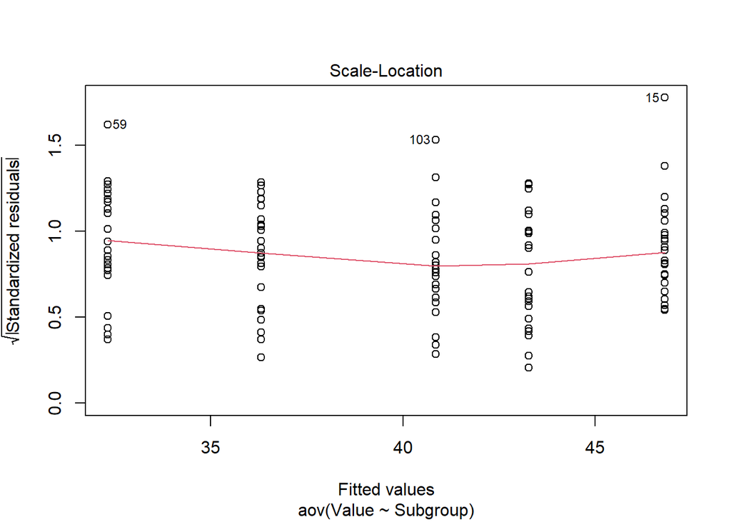

Similar to the first residual plot with the standardized residuals, applying the square root function to the residuals does not show anything concerning.

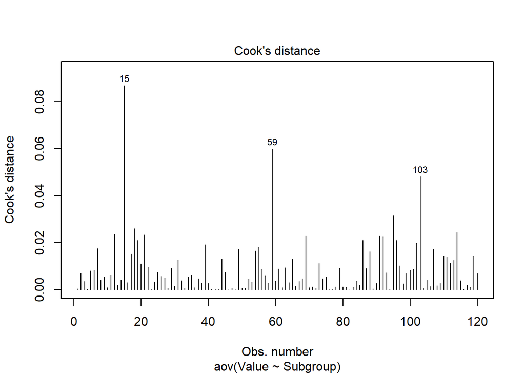

While the Cook's distance plot, upon first glance, shows a couple potential influential points, a quick look at the Y-Axis shows that none of these values are disturbingly high.

Overall, the ANOVA race model's assumption appear to hold up well. The error terms appear to be independent and normally distributed. No major outliers appear to exist and the variance of error terms look equal.

Next, we will look at the plots for the ANOVA age model to help determine if our model assumptions hold.

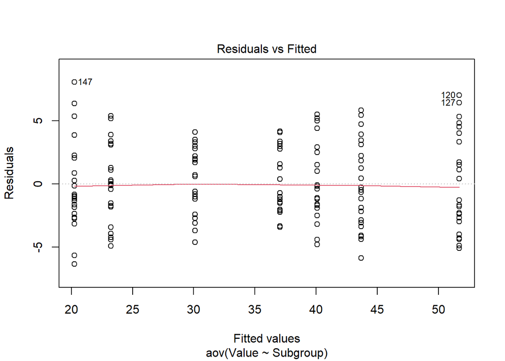

Our residual vs fitted plot shows again a nearly flat line which indicates that the error terms are independent and randomly distributed.

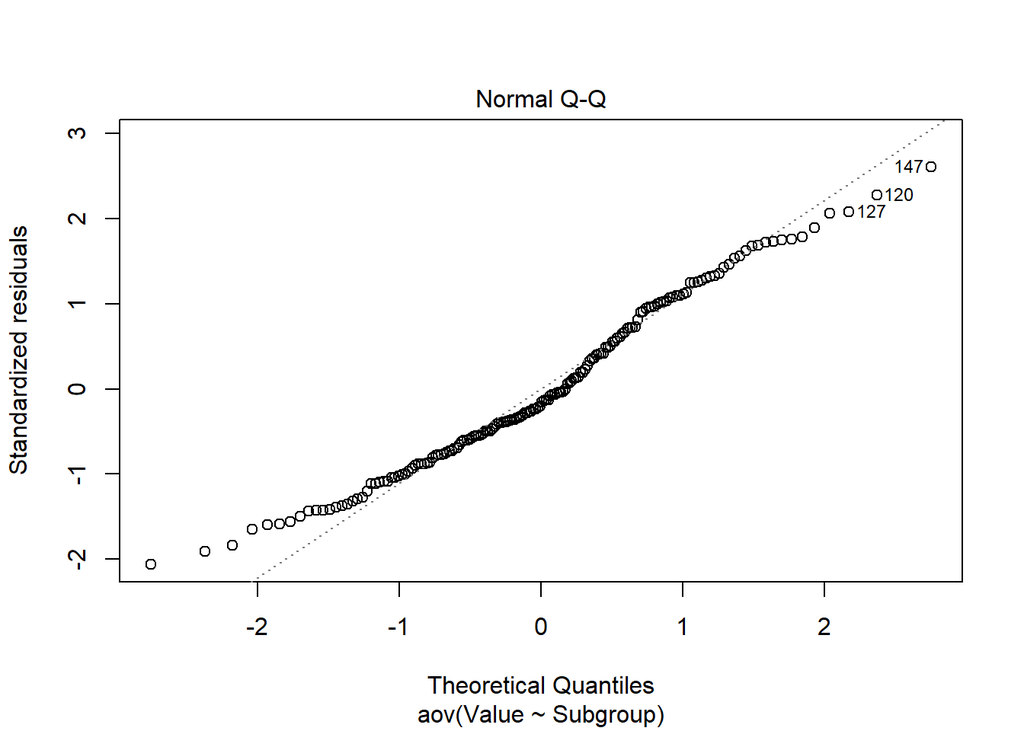

The Normal Q-Q plot shows some tailing on either side but nothing alarming. The assumption that the error terms are normally distributed appears to hold.

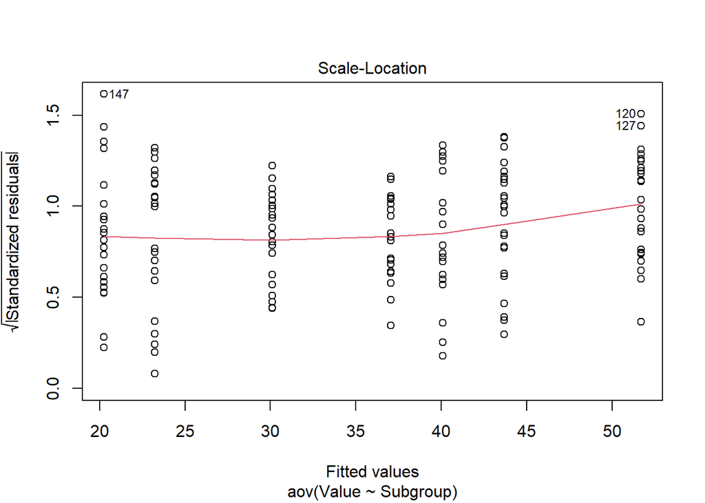

After standardizing the residuals, the plot's line looks less flat than the unstandardized residuals but overall nothing concerning.

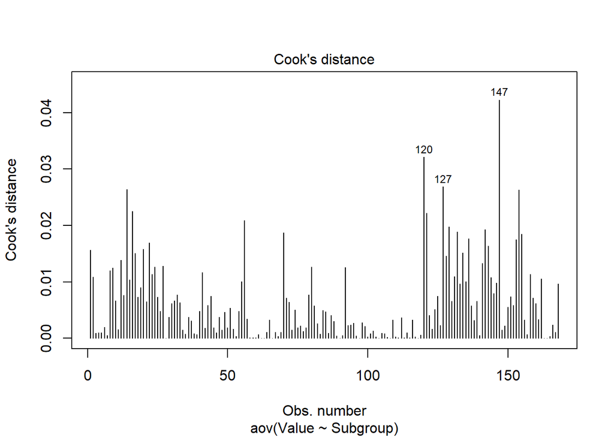

The Cook's distance plot also shows, with a maximum of approimately 0.04, that no points are overly influential.

To summarize the sensitivity analysis suggestion, our assumptions for both the linear model and the two ANOVA models appear to hold and nothing majorly concerning appears that would disqualify the results from the three models.

# Insights and Suggestions for Future Analysis

All our assumptions appear to hold for the model that related log-transformed case counts and anxiety rates in the country. While some data points come close to the Cook's distance line of 0.5 and our residual plot is not as great as it could be, there is not strong enough evidence in these plots to reject the model and it's assumptions.

One way to be more conclusive about the assumptions is to have more data points, the data we collected is only weekly and the case-counts were aggregated weekly to allow for a proper comparison. More data points may be helpful, but weekly case data tends to be similar to daily case data and may not end up having that much of an impact on the conclusions. However, more data points would allow the model validation to be improved. In addition a further analysis could be completed to see how values for Anxiety Disorder and Depression Disorder effect different populations such as looking at differences accross age groups or ethnicities.

# Conclusion

Our analysis shows a relationship between the number of COVID-19 cases and indicators of depression and anxiety among people living in the United States. We aggregated the daily case counts from the WHO Coronavirus Dashboard with the frequency of anxiety and depression symptoms reported in the HPS data set, and then used this aggregated data to create a linear model to analyze the relationship between case rates and the rate of anxiety or depression symptoms. We found a relationship between these two variables with an extremely low p-value and a high adjusted $R^2$ of 0.8475. The model assumptions appear to hold, so the low p-value suggests that we may conclusively reject the null hypothesis of no relationship existing between COVID-19 cases and indicators of anxiety or depression. In addition, the high Adjusted $R^2$ suggests that COVID-19 cases and symptoms of depression or anxiety are highly correlated.

Caveats of our analysis include not being able to infer causality between COVID-19 cases and symptoms of depression or anxiety and not measuring the effects of potential confounders. Barriers to making causal statements arise from the lack of information produced by the HPS on respondents’ employment status, social support, family and living arrangements, pre-existing mental health symptoms and diagnoses, and community characteristics, all of which may be related to emotional distress [(Bui et al., 2020](https://doi.org/10.1093/geront/gnaa217); [Ganson et al., 2021](https://doi.org/10.1016/j.jadohealth.2020.10.008)). Potential confounders that may be important to address in future analysis are the effects of season or pre-existing mental health conditions. For example, weather fluctuations might influence both COVID-19 transmission and the prevalence of seasonal affective disorder, so future analysis that incorporates seasonal effects such as temperature and hours of daylight might produce more precise results. Additionally, chronic stress associated with pre-existing mental health conditions weakens individuals’ immune systems and might lead to more frequent symptoms of depression or anxiety; therefore, future analysis incorporating effects of pre-existing mental health conditions such as biological or psychological markers of stress might also produce more precise results.

Depression and anxiety have been studied extensively and many factors are known to contribute to their development. Some of these factors, such as staying indoors extensively and loss of employment, are byproducts of the government restrictions and lockdowns due to COVID-19. Other factors such as the deaths of loved ones are unfortunately inevitable consequences of the COVID-19 pandemic. These external factors may further obfuscate the true cause of the increased frequency of depression and anxiety symptoms since the start of the pandemic, so it is important to recognize that we cannot conclude that COVID-19 cases *cause* increased depression or anxiety rates. However, we can acknowledge that the COVID-19 pandemic has introduced multifaceted challenges to healthcare and policy, and that mental health should not be ignored in efforts to understand and solve them.

# References

Abbott, A. (2021). COVID’s mental-health toll: how scientists are tracking a surge in depression. Nature, 590(7845), 194–195. https://doi.org/10.1038/d41586-021-00175-z

Brodeur, A., Clark, A. E., Fleche, S., & Powdthavee, N. (2021). COVID-19, lockdowns and well-being: Evidence from Google Trends. Journal of Public Economics, 193, 104346. https://doi.org/10.1016/j.jpubeco.2020.104346

Bui, C. N., Peng, C., Mutchler, J. E., & Burr, J. A. (2020). Race and Ethnic Group Disparities in Emotional Distress Among Older Adults During the COVID-19 Pandemic. The Gerontologist, 61(2), 262–272. https://doi.org/10.1093/geront/gnaa217

Clemente-Suárez, V. J., Dalamitros, A. A., Beltran-Velasco, A. I., Mielgo-Ayuso, J., & Tornero-Aguilera, J. F. (2020). Social and Psychophysiological Consequences of the COVID-19 Pandemic: An Extensive Literature Review. Frontiers in Psychology, 11, 1–15. https://doi.org/10.3389/fpsyg.2020.580225

Delmastro, M., & Zamariola, G. (2020). Depressive symptoms in response to COVID-19 and lockdown: a cross-sectional study on the Italian population. Scientific Reports, 10(1), 1–10. https://doi.org/10.1038/s41598-020-79850-6

Fields JF, Hunter-Childs J, Tersine A, Sisson J, Parker E, Velkoff V, Logan C, and Shin H. Design and Operation of the 2020 Household Pulse Survey, 2020. U.S. Census Bureau. Forthcoming. Ganson, K. T., Tsai, A. C., Weiser, S. D., Benabou, S. E., & Nagata, J. M. (2021). Job Insecurity and Symptoms of Anxiety and Depression Among U.S. Young Adults During COVID-19. Journal of Adolescent Health, 68(1), 53–56. https://doi.org/10.1016/j.jadohealth.2020.10.008

Holmes, E. A., O’Connor, R. C., Perry, V. H., Tracey, I., Wessely, S., Arseneault, L., Ballard, C., Christensen, H., Cohen Silver, R., Everall, I., Ford, T., John, A., Kabir, T., King, K., Madan, I., Michie, S., Przybylski, A. K., Shafran, R., Sweeney, A., … Bullmore, E. (2020). Multidisciplinary research priorities for the COVID-19 pandemic: a call for action for mental health science. The Lancet Psychiatry, 7(6), 547–560. https://doi.org/10.1016/s2215-0366(20)30168-1

WHO COVID-19 Dashboard. Geneva: World Health Organization, 2020. Available online: https://covid19.who.int/

# Appendix

```r
# Setup this markdown file:
knitr::opts_chunk$set(
  fig.pos = 'H',
  warning = FALSE,
  message = FALSE,
  eval = TRUE,
  echo = FALSE,
  fig.align='center'
)
# Include all necessary libraries
library(tidyverse)
library(usmap)
library(reshape2)
library(lubridate)
library(rstatix)
library(gt)
# Import WHO COVID Data, CDC Depression and Anxiety Data, and Google Trends
WHO.path <- file.path("..","Data","WHO-COVID-19-global-data.csv")
CDC.path <- file.path("..","Data","CDC_Anxiety.csv")
GOOGLE.path <- file.path("..","Data","Google_US_Depression_Anxiety.csv")
covid <- read.csv(file = WHO.path, fileEncoding="UTF-8-BOM")
indicators <- read.csv(file = CDC.path, header=T)
GOOGLE <- read.csv(file = GOOGLE.path)

# Convert date column to POSIXct
GOOGLE$Week <- as.POSIXct(GOOGLE$Week)
GOOGLE <- subset(GOOGLE, Week >= as.POSIXct("2020-01-01"))

# subset covid data to include only US data
covid_US = subset(covid, Country == "United States of America") %>% select(Date_reported,New_cases,Cumulative_cases,New_deaths,Cumulative_deaths)
covid_US$Date_reported <- as.POSIXct(covid_US$Date_reported, format = "%Y-%m-%d")

# subset CDC anxiety data to include only the measures for anxiety or depressive disorder (combined) and the national measure
indicators_US = subset(indicators, Indicator == "Symptoms of Anxiety Disorder or Depressive Disorder" &
                         Group == "National Estimate" ) %>%     select(Time.Period,Time.Period.Label,Time.Period.Start.Date,Time.Period.End.Date,Value,Low.CI,High.CI,Quartile.Range)

# remove na data from the indicators leaving 24 values for 24 distinct time periods
indicators_US.narm <- indicators_US %>% filter(!is.na(Value))

# Convert start/end date to standard format.
indicators_US.narm$Time.Period.Start.Date <- as.POSIXct(indicators_US.narm$Time.Period.Start.Date, format = "%m/%d/%Y")
indicators_US.narm$Time.Period.End.Date <- as.POSIXct(indicators_US.narm$Time.Period.End.Date, format = "%m/%d/%Y")
# Present Depression or Anxiety Information by Race
indicators.race <- subset(indicators, Indicator == "Symptoms of Anxiety Disorder or Depressive Disorder" &
                         Group == "By Race/Hispanic ethnicity", c(Subgroup, Value)) %>% filter(!is.na(Value))
indicators.race$Subgroup <- as.character(indicators.race$Subgroup)
indicators.race.means <- aggregate(indicators.race, list(indicators.race$Subgroup), mean)
ggplot(indicators.race.means, aes(x=Value, y=Group.1, )) +
  geom_bar(aes(fill=Group.1), stat = "identity", position = "dodge") +
  theme(legend.position = "none") +
  labs(title = "Depression or Anxiety Symptoms by Race",
       subtitle = "Average 2020 Household Pulse Survey",
       x = "Average % of Survey Responses Indicating Anxiety or Depression",
       y = "")

# Present Depression or Anxiety Information by Sex
indicators.sex <- subset(indicators, Indicator == "Symptoms of Anxiety Disorder or Depressive Disorder" &
                         Group == "By Gender",c(Subgroup, Value))  %>% filter(!is.na(Value))
indicators.sex.means <- aggregate(indicators.sex, list(indicators.sex$Subgroup), mean)
# ggplot(indicators.sex.means, aes(x=Value, y=Group.1)) +
#  geom_bar(aes(fill=Group.1), stat = "identity", position = "dodge") +
#  theme(legend.position = "none") +
#  labs(title = "Depression or Anxiety Symptoms by Sex",
#       subtitle = "Average 2020 Household Pulse Survey",
#       x = "Average % of Survey Responses Indicating Anxiety or Depression",
#       y = "")

# Present Depression or Anxiety Information by State
indicators.state <- subset(indicators, Indicator == "Symptoms of Anxiety Disorder or Depressive Disorder" &
                         Group == "By State", c(Subgroup,Value))  %>% filter(!is.na(Value))
indicators.state.means <- aggregate(indicators.state, list(indicators.state$Subgroup), mean) %>% select(Group.1,Value)
indicators.state.means$Group.1 <- usmap::fips(indicators.state.means$Group.1)
names(indicators.state.means) <- c('fips','Value')
usmap::plot_usmap(data=indicators.state.means, values="Value") +
  theme(legend.position = 'right') +
  labs(title = "Depression or Anxiety Symptoms by State", subtitle = "Average 2020 Household Pulse Survey") +
  scale_fill_continuous(low = "yellow", high = "blue", name = "Anxiety or Depression Percentage")
# Fill in dates of indicators and GOOGLE
HPS <- list()
for (i in 1:(dim(indicators_US.narm)[1]-1)) {
  fill.dates <- seq(indicators_US.narm[i,'Time.Period.Start.Date'], indicators_US.narm[i+1,'Time.Period.Start.Date'] - 1*60*60*24, by="days")
  fill.values <- c(rep(1,length(fill.dates)))*indicators_US.narm[i,'Value']
  fill.dates.df <- data.frame(fill.dates,fill.values)
  HPS[[i]] <- fill.dates.df
}
HPS.full <- bind_rows(HPS)

Trends.Anxiety <- list()
Trends.Depression <- list()
for (i in 1:(dim(GOOGLE)[1]-1)) {
  fill.dates <- seq(GOOGLE[i,'Week'], GOOGLE[i+1,'Week'] - 1*60*60*24, by="days")
  fill.anxiety.values <- c(rep(1,length(fill.dates)))*GOOGLE[i,'Anxiety...United.States.']
  fill.depression.values <- c(rep(1,length(fill.dates)))*GOOGLE[i,'Depression...United.States.']
  fill.dates.df <- data.frame(fill.dates,fill.anxiety.values)
  Trends.Anxiety[[i]] <- fill.dates.df
  fill.dates.df <- data.frame(fill.dates,fill.depression.values)
  Trends.Depression[[i]] <- fill.dates.df
}
Trends.Anxiety.Full <- bind_rows(Trends.Anxiety)
Trends.Depression.Full <- bind_rows(Trends.Depression)

# Combine into one dataframe
all.covid <- covid_US %>% subset(Date_reported >= as.POSIXct("2020-04-23") & Date_reported < as.POSIXct("2021-01-01"),c(Date_reported,New_cases,New_deaths))
all.Anxiety <- Trends.Anxiety.Full %>% subset(fill.dates >= as.POSIXct("2020-04-23") & fill.dates < as.POSIXct("2021-01-01"))
all.Depression <- Trends.Depression.Full %>% subset(fill.dates >= as.POSIXct("2020-04-23") & fill.dates < as.POSIXct("2021-01-01"))
all.HPS <- HPS.full %>% subset(fill.dates >= as.POSIXct("2020-04-23") & fill.dates < as.POSIXct("2021-01-01"))
all.df <- data.frame(all.covid,all.Anxiety$fill.anxiety.values,all.Depression$fill.depression.values,all.HPS$fill.values)
names(all.df) <- c("Date","New Cases","New Deaths","Anxiety Google Trends","Depression Google Trends","Household Pulse Survey")
# Show daily deaths, cases, anxiety|depression, and google trends overtime
all.df.m <- melt(all.df %>% select(1:3), "Date")
# New_cases,New_deaths,all.Anxiety.fill.anxiety.values,all.Depression.fill.depression.values,all.HPS.fill.values
#options(repr.plot.width = 8, repr.plot.height = 0.75)
ggplot(all.df.m, aes(Date,value,colour = variable)) +
  geom_point() +
  facet_wrap(~ variable, ncol=1,scales = "free_y") +
  labs(title = "COVID-19 Deaths and Cases",
       subtitle = "WHO Data in 2020",
       y = "") +
  theme(text = element_text(size = 12), element_line(size = 0.2))
```

```r
percentages <- data.frame(all.covid$Date,all.Anxiety$fill.anxiety.values,all.Depression$fill.depression.values,all.HPS$fill.values)
names(percentages) <-c("Date","Anxiety Google Trends","Depression Google Trends","Household Pulse Survey")
percent.m <- melt(percentages,"Date")

ggplot(percent.m, aes(Date,value,colour = variable)) +
  geom_point() +
  labs(title = "HPS Results and Google Trends",
       subtitle = "HPS and Google Trends on 'Anxiety' and 'Depression' Topics in 2020",
       y = "% of responders indicating symptoms and Google's weighted %") +
  theme(text = element_text(size = 12), element_line(size = 0.2))
covid.US.Months <- data.frame(covid_US) %>% subset(Date_reported >= as.POSIXct("2020-01-01") & Date_reported < as.POSIXct("2021-01-01"),c(Date_reported,New_cases,New_deaths))
covid.US.Months$Date_reported <- format(covid.US.Months$Date_reported, "01-%m-%Y")
covid.US.Months.stats.cases <- covid.US.Months %>%
                                select(Date_reported,New_cases) %>%
                                group_by(Date_reported) %>%
                                get_summary_stats(type='common')
covid.US.Months.stats.deaths <- covid.US.Months %>%
                                  select(Date_reported,New_deaths) %>%
                                  group_by(Date_reported) %>%
                                  get_summary_stats(type='common')
# covid.US.Months.stats.cases %>%
#   select('Date_reported','min','max','median','mean','sd') %>%
#   gt() %>%
#   tab_header(
#     title = "2020 COVID-19 Cases",
#     subtitle = "Values per day of each month"
#   ) %>%
#   fmt_date(
#     columns = vars(Date_reported),
#     date_style = 11
#   ) %>%
#   fmt_number(
#     columns = vars(min,max,median,mean,sd),
#     decimals = 0
#   )
#
# covid.US.Months.stats.deaths %>%
#   select('Date_reported','min','max','median','mean','sd') %>%
#   gt() %>%
#   tab_header(
#     title = "2020 COVID-19 Deaths",
#     subtitle = "Values per day of each month"
#   ) %>%
#   fmt_date(
#     columns = vars(Date_reported),
#     date_style = 11
#   ) %>%
#   fmt_number(
#     columns = vars(min,max,median,mean,sd),
#     decimals = 0
#   )
dates1 = covid_US[112:124,]
dates2 = covid_US[126:131,]
dates3 = covid_US[133:138,]
dates4 = covid_US[140:145,]
dates5 = covid_US[147:152,]
dates6 = covid_US[154:159,]
dates7 = covid_US[161:166,]
dates8 = covid_US[168:173,]
dates9 = covid_US[175:180,]
dates10 = covid_US[182:187,]
dates11 = covid_US[189:194,]
dates12 = covid_US[196:201,]
dates13 = covid_US[230:242,]
dates14 = covid_US[244:256,]
dates15 = covid_US[258:270,]
dates16 = covid_US[272:284,]
dates17 = covid_US[286:298,]
dates18 = covid_US[300:312,]
dates19 = covid_US[314:326,]
dates20 = covid_US[328:340,]
dates21 = covid_US[342:354,]
dates22 = covid_US[370:382,]
dates23 = covid_US[384:396,]
dates24 = covid_US[398:410,]

dates1_cases = mean(dates1$New_cases)
dates1_deaths = mean(dates1$New_deaths)

dates2_cases = mean(dates2$New_cases)
dates2_deaths = mean(dates2$New_deaths)

dates3_cases = mean(dates3$New_cases)
dates3_deaths = mean(dates3$New_deaths)

dates4_cases = mean(dates4$New_cases)
dates4_deaths = mean(dates4$New_deaths)

dates5_cases = mean(dates5$New_cases)
dates5_deaths = mean(dates5$New_deaths)

dates6_cases = mean(dates6$New_cases)
dates6_deaths = mean(dates6$New_deaths)

dates7_cases = mean(dates7$New_cases)
dates7_deaths = mean(dates7$New_deaths)

dates8_cases = mean(dates8$New_cases)
dates8_deaths = mean(dates8$New_deaths)

dates9_cases = mean(dates9$New_cases)
dates9_deaths = mean(dates9$New_deaths)

dates10_cases = mean(dates10$New_cases)
dates10_deaths = mean(dates10$New_deaths)

dates11_cases = mean(dates11$New_cases)
dates11_deaths = mean(dates11$New_deaths)

dates12_cases = mean(dates12$New_cases)
dates12_deaths = mean(dates12$New_deaths)

dates13_cases = mean(dates13$New_cases)
dates13_deaths = mean(dates13$New_deaths)

dates14_cases = mean(dates14$New_cases)
dates14_deaths = mean(dates14$New_deaths)

dates15_cases = mean(dates15$New_cases)
dates15_deaths = mean(dates15$New_deaths)

dates16_cases = mean(dates16$New_cases)
dates16_deaths = mean(dates16$New_deaths)

dates17_cases = mean(dates17$New_cases)
dates17_deaths = mean(dates17$New_deaths)

dates18_cases = mean(dates18$New_cases)
dates18_deaths = mean(dates18$New_deaths)

dates19_cases = mean(dates19$New_cases)
dates19_deaths = mean(dates19$New_deaths)

dates20_cases = mean(dates20$New_cases)
dates20_deaths = mean(dates20$New_deaths)

dates21_cases = mean(dates21$New_cases)
dates21_deaths = mean(dates21$New_deaths)

dates22_cases = mean(dates22$New_cases)
dates22_deaths = mean(dates22$New_deaths)

dates23_cases = mean(dates23$New_cases)
dates23_deaths = mean(dates23$New_deaths)

dates24_cases = mean(dates24$New_cases)
dates24_deaths = mean(dates24$New_deaths)

dates = c("dates1", "dates2", "dates3", "dates4", "dates5", "dates 6", "dates7", "dates8", "dates9", "dates10", "dates11", "dates12", "dates13", "dates14", "dates15", "dates16", "dates17", "dates18", "dates19", "dates20", "dates21", "dates22", "dates23", "dates24")

cases = c(dates1_cases, dates2_cases, dates3_cases, dates4_cases, dates5_cases, dates6_cases, dates7_cases, dates8_cases, dates9_cases, dates10_cases, dates11_cases, dates12_cases, dates13_cases, dates14_cases, dates15_cases, dates16_cases, dates17_cases, dates18_cases, dates19_cases, dates20_cases, dates21_cases, dates22_cases, dates23_cases, dates24_cases)

deaths = c(dates1_deaths, dates2_deaths, dates3_deaths, dates4_deaths, dates5_deaths, dates6_deaths, dates7_deaths, dates8_deaths, dates9_deaths, dates10_deaths, dates11_deaths, dates12_deaths, dates13_deaths, dates14_deaths, dates15_deaths, dates16_deaths, dates17_deaths, dates18_deaths, dates19_deaths, dates20_deaths, dates21_deaths, dates22_deaths, dates23_deaths, dates24_deaths)

anxiety_value = indicators_US.narm$Value

compiled_data = data.frame(dates, cases, deaths, anxiety_value)
#Plot showing new cases vs anxiety value
plot(x=cases, y=anxiety_value, main="cases ~ anxiety_value")
```

```r
#Plot showing new deaths vs anxiety value
plot(x=deaths, y=anxiety_value, main="deaths ~ anxiety_value")
linearMod_cases = lm(log(cases) ~ anxiety_value, data=compiled_data)
summary(linearMod_cases)
linearMod_deaths <- lm(log(deaths) ~ anxiety_value, data=compiled_data)
summary(linearMod_deaths)
#subsetting the CDC anxiety data to include only the measures for anxiety or depressive disorder (combined) grouped by race
indicators_race = subset(indicators, Indicator == "Symptoms of Anxiety Disorder or Depressive Disorder" &
                         Group == "By Race/Hispanic ethnicity" )
indicators_race.narm <- indicators_race %>% filter(!is.na(Value))
anova_race = aov(Value ~ Subgroup, data = indicators_race.narm)
summary(anova_race)

library(emmeans)
emmeans(anova_race, pairwise ~ "Subgroup")
#subsetting the CDC anxiety data to include only the measures for anxiety or depressive disorder (combined) grouped by age
indicators_age = subset(indicators, Indicator == "Symptoms of Anxiety Disorder or Depressive Disorder" &
                         Group == "By Age" )
indicators_age.narm <- indicators_age %>% filter(!is.na(Value))
anova_age = aov(Value ~ Subgroup, data = indicators_age.narm)
summary(anova_age)

emmeans(anova_age, pairwise ~ "Subgroup")
  ggplot(data = compiled_data, aes(x = anxiety_value, y=cases)) +
    geom_point(color = 'blue') +
    geom_smooth(method = "lm", se = FALSE, color = 'red')
  ggplot(data = compiled_data, aes(x = anxiety_value, y=log(cases))) +
    geom_point(color = 'blue') +
    geom_smooth(method = "lm", se = FALSE, color = 'red')
  plot(linearMod_cases, which = 1)
  plot(linearMod_cases, which = 2)
  plot(linearMod_cases, which = 3)
  plot(linearMod_cases, which = 5)
  plot(anova_race, which = 1)
  plot(anova_race, which = 2)
  plot(anova_race, which = 3)
  plot(anova_race, which = 4)
  plot(anova_age, which = 1)
  plot(anova_age, which = 2)
  plot(anova_age, which = 3)
  plot(anova_age, which = 4)
```